# Atividade 7

Leonardo P. Migliorini

### Representação gráfica dos dados

Os gráficos apresentados descrevem a distribuição proporcional dos estados de saúde dos indivíduos, estratificados por uso de tabaco (sim ou não) e presença de problema cardíaco (sim ou não). Cada barra representa a proporção de casos por categoria de estado de saúde (Excelente, Bom, Moderado e Ruim).

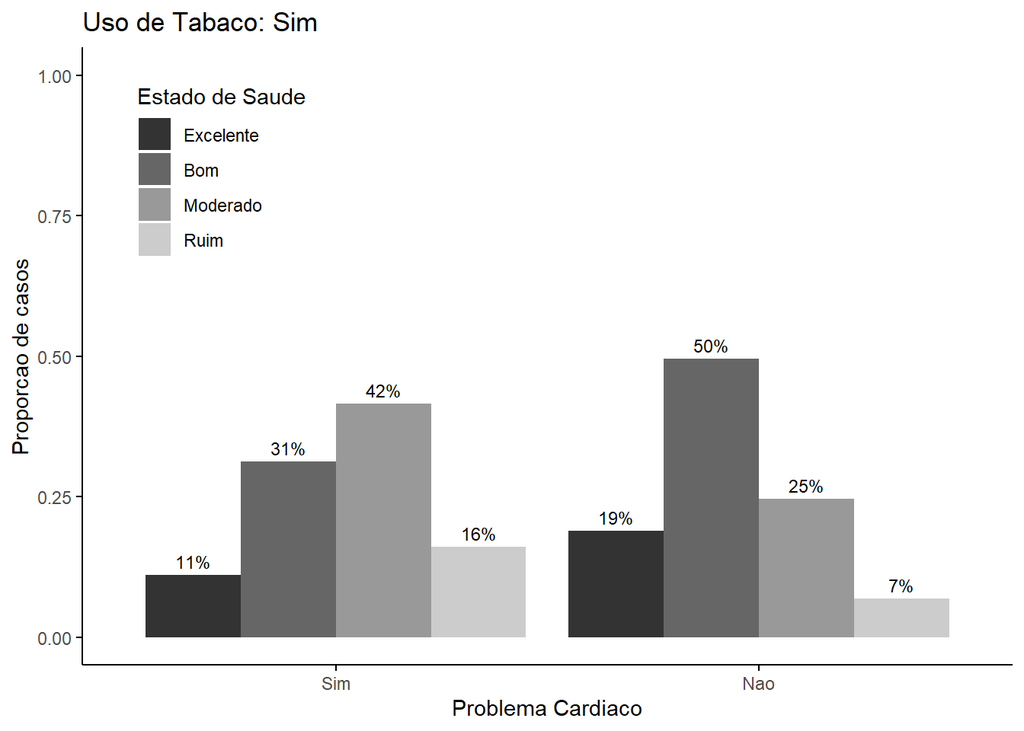

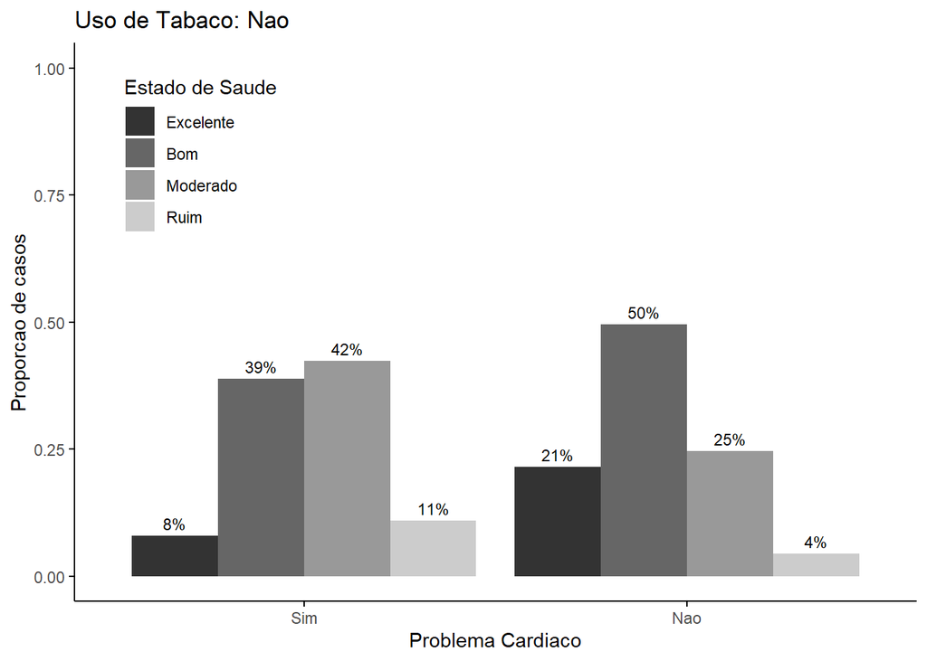

No grupo de indivíduos não tabagistas, observa-se que entre aqueles com problema cardíaco, a maioria se encontra em estado de saúde Moderado (42%) e Bom (39%). Por outro lado, entre os que não possuem problema cardíaco, 50% estão em estado Bom, 25% em Moderado, 21% em Excelente e apenas 4% em Ruim, o que sugere uma melhor condição geral de saúde nesse subgrupo.

Já entre os indivíduos tabagistas, aqueles com problema cardíaco também apresentam maior concentração nos estados Moderado (42%) e Bom (31%), mas com aumento na proporção de casos classificados como Ruim (16%) e leve aumento em Excelente (11%). Para os que não possuem problema cardíaco, as proporções se mantêm semelhantes às do grupo sem tabaco.

De modo geral, indivíduos sem problema cardíaco e que não utilizam tabaco tendem a apresentar melhor estado de saúde, com maiores proporções nas categorias Excelente e Bom, e menores proporções em Ruim. Já o uso de tabaco parece estar associado a um aumento das proporções de estados de saúde Moderado e Ruim, especialmente entre aqueles com problema cardíaco.

### Ajuste Modelo Logitos Cumulativos

Abaixo temos a análise de deviance para os MCPP encaixados.

|  | GL | Deviance | TRV | Dif | P-v | AIC |
| --- | --- | --- | --- | --- | --- | --- |
| Nulo | 9 | 380 | NA | NA | NA | 470 |
| Z | 6 | 353 | 26.51 | 3 | 0.000 | 449 |
| X\|Z | 5 | 7 | 346.59 | 1 | 0.000 | 104 |
| Z*X\|Z,X | 4 | 6 | 0.10 | 1 | 0.752 | 106 |

Observa-se que o modelo 1 apresentou diferença significativa no deviance em relação ao modelo nulo, indicando que a variável tabaco é importante para explicar o estado geral de saúde. O modelo 3 teve diferença significativa no deviance em relação ao modelo 2, indicando que a presença de problema cardíaco também é significativo para explicar o estado geral de saúde. Já a interação entre as variáveis foi não significativa. Ainda, o modelo 3 foi apresentou o menor valor para o AIC.Portanto, o modelo escolhido ao final é o modelo 3, cuja estrutura dos logitos é expressa por:

$$\begin{equation}
\log\left(\dfrac{P\left(Y \leqslant 1 | x, z\right)}{P\left(Y > 1
| x,z\right)}\right) = -1,3 -0,13Z -1,03X,
\end{equation}$$

$$\begin{equation}
\log\left(\dfrac{P\left(Y \leqslant 2 | x, z\right)}{P\left(Y > 2
| x,z\right)}\right) = 0,90 -0,13Z -1,03X,
\end{equation}$$

$$\begin{equation}
\log\left(\dfrac{P\left(Y \leqslant 3 | x,z\right)}{P\left(Y > 3
| x,z\right)}\right) = 3,08 - 0,46Z -1,03X,
\end{equation}$$

em que $Z = 0$ indica não tabagista e $Z = 1$ indica tabagista, $X = 0$ indica ausência de problema cardíaco e $X = 1$ indica problema cardíaco.

Abaixo, temos os gráficos para os resíduos de Pearson para o modelo 2. Podemos ver que todos os valores estão entre $[-2,2]$ indicando um bom ajuste do modelo.

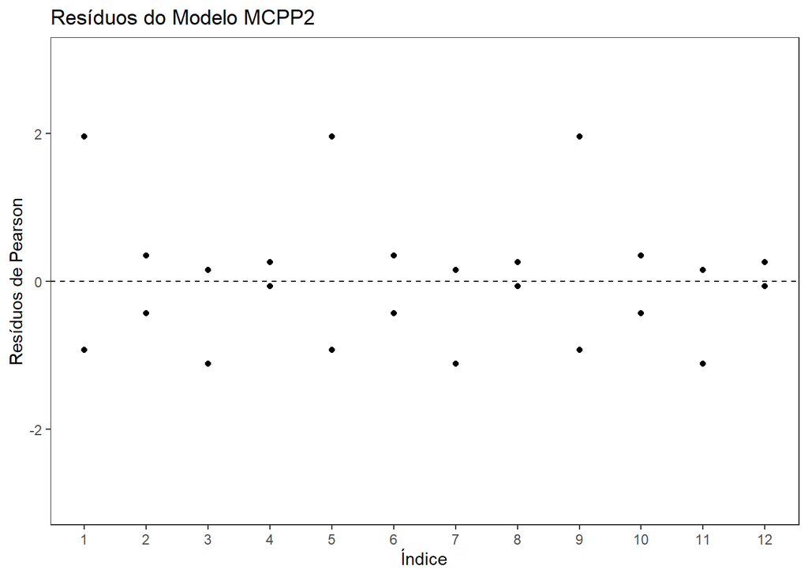

#### Interpretação do ajuste:

Logito 2:

Na segunda equação, temos à chance de estar no estado de saúde bom ou superior em relação a um estado inferior. Para tabagistas e sem ploblemas cardíacos temos uma chance 2,16 de estarem com estado de saúde pelo menos bom. Para tabagistas e com ploblemas cardíacos, temos uma chance de 0,77 do indivíduo apresentar estado de saúde ao menos bom. Para não tabagistas e sem problemas cardíacos, temos uma chance de 2,45 de apresentar estado de saúde bom ou melhor, e para não tabagistas com problemas cardíacos temos uma chance de 0,88.

Logito 3:

Por fim, a terceira equação modela a chance de estar com estado de saúde moderado ou melhor em relação a estar na categoria ruim. Nesse caso, tabagistas com ausência de ploblemas cardíacos tem uma chance 13,73 de estarem com estado de saúde moderado ou superior. Para tabagistas e com ploblemas cardíacos, temos uma chance de 4,90 do indivíduo apresentar estado de saúde moderado ou superior. Para não tabagistas e sem problemas cardíacos, temos uma chance de 21,76 de apresentar estado de saúde como moderado ou superior, e para não tabagistas com problemas cardíacos temos uma chance de 7,76.

Os resultados obtidos por meio do modelo de logitos cumulativos indicam que a presença de problema cardíaco está associada a menores chances de os indivíduos se encontrarem em melhores estados de saúde, independentemente do tabagismo. Além disso, observa-se que, para uma mesma condição cardíaca, indivíduos não tabagistas tendem a apresentar maiores chances de estarem em melhores categorias de saúde em comparação aos tabagistas. Esses achados estão em conformidade com a expectativa clínica de que tanto o tabagismo quanto os problemas cardíacos estão negativamente associados à condição geral de saúde.

### Ajuste Modelo Logito com categorias adjascentes

Ajustamos os modelos para $X_1$, $X_2$ e para $X_1 + X_2$. Para o modelo somente com $X_1$, obteve-se um TRV = 11,09 ($p = 0,003, \; g.l = 2$), fornecendo evidência a favor do modelos com chances não proporcionais para $X_1$. Para o modelo somente com $X_2$, obteve-se um TRV = 11,53 ($p = 0,003, \; g.l = 2$), fornecendo evidência a favor do modelos com chances não proporcionais para $X_2$. Por fim, o modelo somente para $X_1 + X_2$ obteve-se um TRV = 22,58 ($p \leq 0,001, \; g.l = 4$), fornecendo evidência a favor do modelos com chances não proporcionais para a combinação de $X_1 + X_2$. Portanto, vamos adotar o MCNP para modelagem dos dados.

Abaixo temos a análise de deviance para os MCNP encaixados.

|  | GL | Deviance | TRV | Dif | P-v | AIC |
| --- | --- | --- | --- | --- | --- | --- |
| Nulo | 9 | 380 | NA | NA | NA | 470 |
| X1 | 6 | 353 | 26.51 | 3 | 0.000 | 449 |
| X2\|X1 | 3 | 6 | 346.75 | 3 | 0.000 | 108 |
| X1*X2\|X1,X2 | 0 | 0 | 6.37 | 3 | 0.095 | 108 |

Observa-se que o modelo 1 apresentou diferença significativa no deviance em relação ao modelo nulo, indicando que a variável tabaco é importante para explicar o estado geral de saúde. O modelo 3 teve diferença significativa no deviance em relação ao modelo 2, indicando que a presença de problema cardíaco também é significativo para explicar o estado geral de saúde. Já a interação entre as variáveis foi não significativa. Ainda, o modelo 3 foi apresentou o menor valor para o AIC. Portanto, o modelo escolhido ao final é o modelo 3, cuja estrutura dos logitos é expressa por:

$$\begin{equation}
\log\left(\dfrac{P\left(Y = 1 | x\right)}{P\left(Y = 2 |
x\right)}\right) = 0,84 + 0,08X_1 + 0,62X_2,
\end{equation}$$

$$\begin{equation}
\log\left(\dfrac{P\left(Y = 2 | x\right)}{P\left(Y = 3 |
x\right)}\right) = 0,70 + 0,02X_1 + 0,82X_2,
\end{equation}$$

$$\begin{equation}
\log\left(\dfrac{P\left(Y = 3 | x\right)}{P\left(Y = 4 |
x\right)}\right) = -1,71 + 0,43X_1 + 0,35X_2,
\end{equation}$$

em que $X_1 = 0$ indica não tabagista e $X_1 = 1$ indica tabagista, $X_2 = 0$ indica ausência de problema cardíaco e $X_2 = 1$ indica problema cardíaco.

Abaixo, temos os gráficos para os resíduos de Pearson para o modelo 2. Podemos ver que todos os valores estão entre $[-2,5;2,5]$ indicando um bom ajuste do modelo.

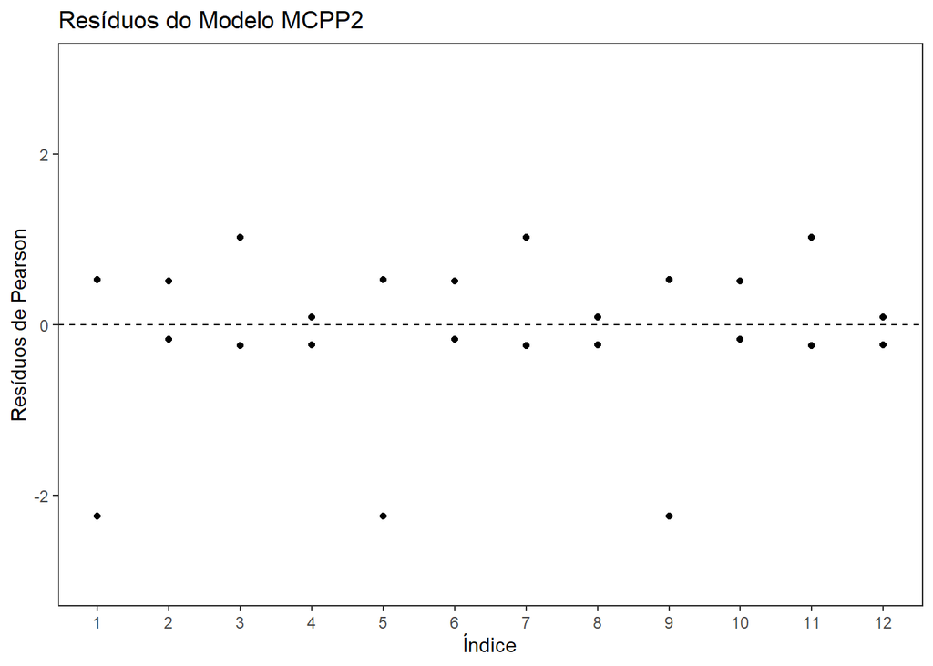

#### Interpretação do ajuste:

Logito 1:

Na primeira equação, modela-se a chance de estar em estado de saúde excelente em relação ao bom. Observa-se que indivíduos tabagistas ($X_1 = 1$) e sem ploblemas cardíacos ($X_2 = 0$) tem chance igual a 2,51 de estarem com estado de saúde excelente em comparação ao bom. Para tabagistas ($X_1 = 1$) e com ploblemas cardíacos ($X_2 = 1$), temos uma chance de 4,66 do indivíduo apresentar estado de saúde excelente sobre o bom. Para não tabagistas e sem problemas cardíacos, temos uma chance de 2,32 de apresentar estado de saúde excelente, e para não tabagistas com problemas cardíacos temos uma chance de 4,30.

Logito 3:

A terceira equação compara os estados moderado e ruim. Temos que indivíduos tabagistas e sem ploblemas cardíacos a chance é de 0,28 de estarem com estado de saúde moderado em comparação ao ruim. Para tabagistas e com ploblemas cardíacos, temos uma chance de 0,39 do indivíduo apresentar estado de saúde moderado sobre o ruim. Para não tabagistas e sem problemas cardíacos, temos uma chance de 0,18 de apresentar estado de saúde moderado, e para não tabagistas com problemas cardíacos temos uma chance de 0,26.

### Ajuste Modelo Logito de razão contínua

Abaixo temos a análise de deviance para os MCNP encaixados.

|  | GL | Deviance | TRV | Dif | P-v | AIC |
| --- | --- | --- | --- | --- | --- | --- |
| Nulo | 9 | 380 | NA | NA | NA | 470 |
| X1 | 6 | 353 | 26.51 | 3 | 0.000 | 449 |
| X2\|X1 | 3 | 6 | 346.99 | 3 | 0.000 | 108 |
| X1*X2\|X1,X2 | 0 | 0 | 6.12 | 3 | 0.106 | 108 |

Observa-se que o modelo 1 apresentou diferença significativa no deviance em relação ao modelo nulo, indicando que a variável tabaco é importante para explicar o estado geral de saúde. O modelo 3 teve diferença significativa no deviance em relação ao modelo 2, indicando que a presença de problema cardíaco também é significativo para explicar o estado geral de saúde. Já a interação entre as variáveis foi não significativa. Ainda, o modelo 3 foi apresentou o menor valor para o AIC. Portanto, o modelo escolhido ao final é o modelo 3, cuja estrutura dos logitos é expressa por:

$$\begin{equation}
\log\left(\dfrac{P\left(Y = 1 | x\right)}{P\left(Y \geqslant 1 |
x\right)}\right) = 1,30 + 0,12X_1 + 1,04X_2,
\end{equation}$$

$$\begin{equation}
\log\left(\dfrac{P\left(Y = 2 | x\right)}{P\left(Y \geqslant 2 |
x\right)}\right) = -0,54 + 0,10X_1 + 0,89X_2,
\end{equation}$$

$$\begin{equation}
\log\left(\dfrac{P\left(Y = 3 | x\right)}{P\left(Y \geqslant 3 |
x\right)}\right) = -1,71 + 0,42X_1 + 0,35X_2,
\end{equation}$$

em que $X_1 = 0$ indica não tabagista e $X_1 = 1$ indica tabagista, $X_2 = 0$ indica ausência de problema cardíaco e $X_2 = 1$ indica problema cardíaco.

Abaixo, temos os gráficos para os resíduos de Pearson para o modelo 2. Podemos ver que todos os valores estão entre $[-2;2]$ indicando um bom ajuste do modelo.

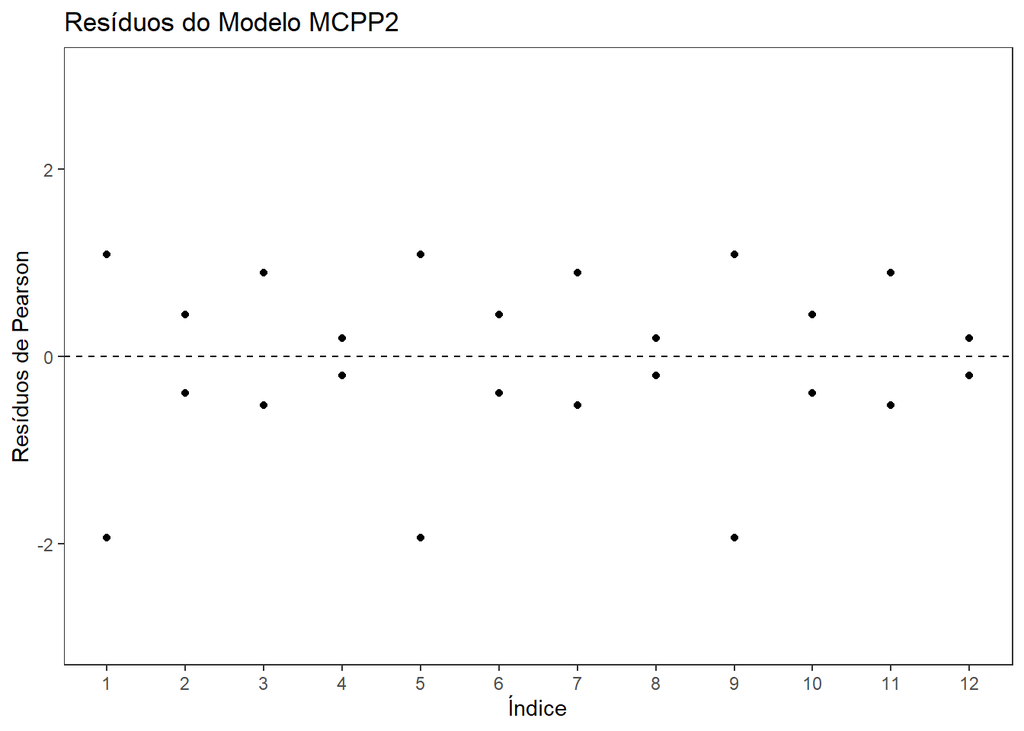

#### Interpretação do ajuste:

Logito 1:

Na primeira equação, que modela a chance de estar em estado de saúde excelente em relação as demais, observa-se que indivíduos tabagistas ($X_1 = 1$) e sem ploblemas cardíacos ($X_2 = 0$) tem chance 4,14 de estarem com estado de saúde excelente em comparação as demais. Para tabagistas ($X_1 = 1$) e com ploblemas cardíacos ($X_2 = 1$), temos uma chance de 11,7 do indivíduo apresentar estado de saúde excelente. Para não tabagistas e sem problemas cardíacos, temos uma chance de 3,67 de apresentar estado de saúde excelente, e para não tabagistas com problemas cardíacos temos uma chance de 10,38.

Logito 2:

Na segunda equação, relacionada à chance de estar no estado de saúde bom em relação a um estado inferior. Para tabagistas e sem ploblemas cardíacos temos uma chance 0,64 de estarem com estado de saúde bom em comparação aos estados inferiores. Para tabagistas e com ploblemas cardíacos, temos uma chance de 1,57 do indivíduo apresentar estado de saúde bom. Para não tabagistas e sem problemas cardíacos, temos uma chance de 0,58 de apresentar estado de saúde bom, e para não tabagistas com problemas cardíacos temos uma chance de 1,42.

Logito 3:

Por fim, a terceira equação modela a chance de estar no estado de saúde moderado em relação a estar na categoria ruim. Nesse caso, tabagistas com ausência de ploblemas cardíacos tem uma chance 0,27 de estarem com estado de saúde moderado em comparação a ruim. Para tabagistas e com ploblemas cardíacos, temos uma chance de 0,39 do indivíduo apresentar estado de saúde moderado. Para não tabagistas e sem problemas cardíacos, temos uma chance de 0,18 de apresentar estado de saúde como moderado, e para não tabagistas com problemas cardíacos temos uma chance de 0,26.